# On the low number of sites covered in many samples

J. Ignacio Lucas Lledó

17/11/2021

```bash
VCFDIR=/data/kristyna/hedgehog/results_2021/2021-04-13

# Raw, dirty vcf, 90 samples:
VCF1=$VCFDIR/all_merged_2021.vcf

if [ ! -e popfile.txt ]; then
   if [ ! -e make_popfile.sh ]; then
      cp ../2021-11-16/make_popfile.sh ./
   fi
   ./make_popfile.sh
fi
```

The reviewers asked, on one side, to be more demanding on the minimum coverage, and on the other side to use methods more appropriate for low coverage data, based on genotype likelihoods, instead of known genotypes. I think a minimum coverage of 6 should be enough when working with genotype likelihoods, like in the ANGSD package.

One of the main limitations of our analyses is the low number of SNPs with genotype data in most samples. It is still unclear if we could optimize the filtering strategies.

Before even running freebayes, I should have removed the individuals with very low number of mapped reads. Let's check that first.

```bash
BAMDIR=/data/kristyna/hedgehog/results_2020/2020-01-30
if [ ! -e mapped.txt ]; then
   echo -e "# Sample\tMapped" > mapped.txt
   for bam in $(ls -1 $BAMDIR/*.bam); do
      echo -e $(basename $bam | sed 's/_msnc.bam//g') "\t" \
         $(samtools flagstat $bam | grep mapped | head -n 1 | cut -d " " -f 1) >> mapped.txt
   done
fi
```

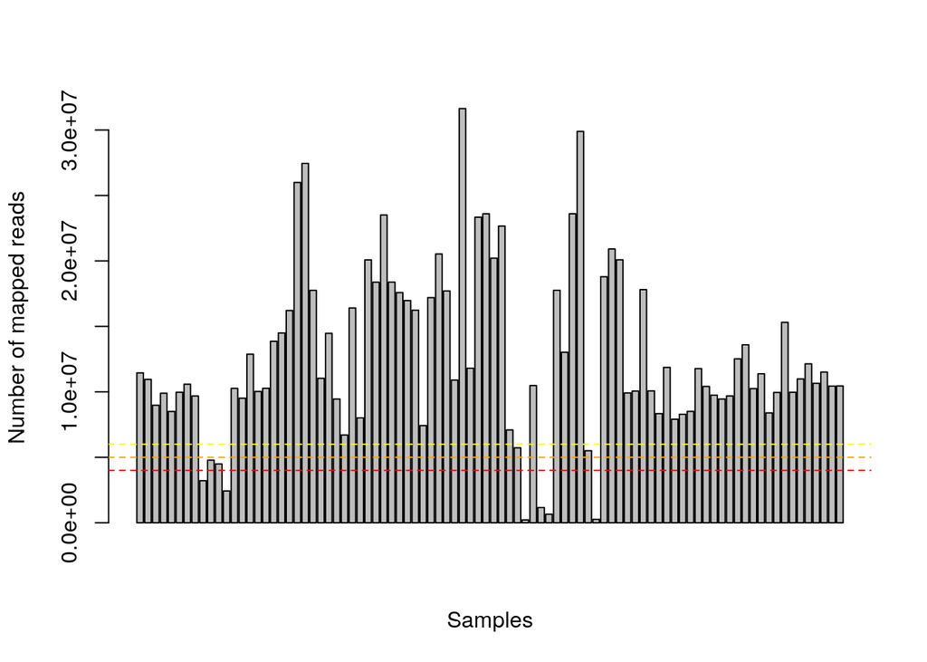

```r
mapped <- read.table('mapped.txt', as.is = TRUE, col.names=c('sample','numReads'))
barplot(mapped$numReads, xlab = 'Samples', ylab = 'Number of mapped reads')
abline(h = 4.0e+06, col = 'red', lty = 2)
abline(h = 5.0e+06, col = 'orange', lty = 2)
abline(h = 6.0e+06, col = 'yellow', lty = 2)
```

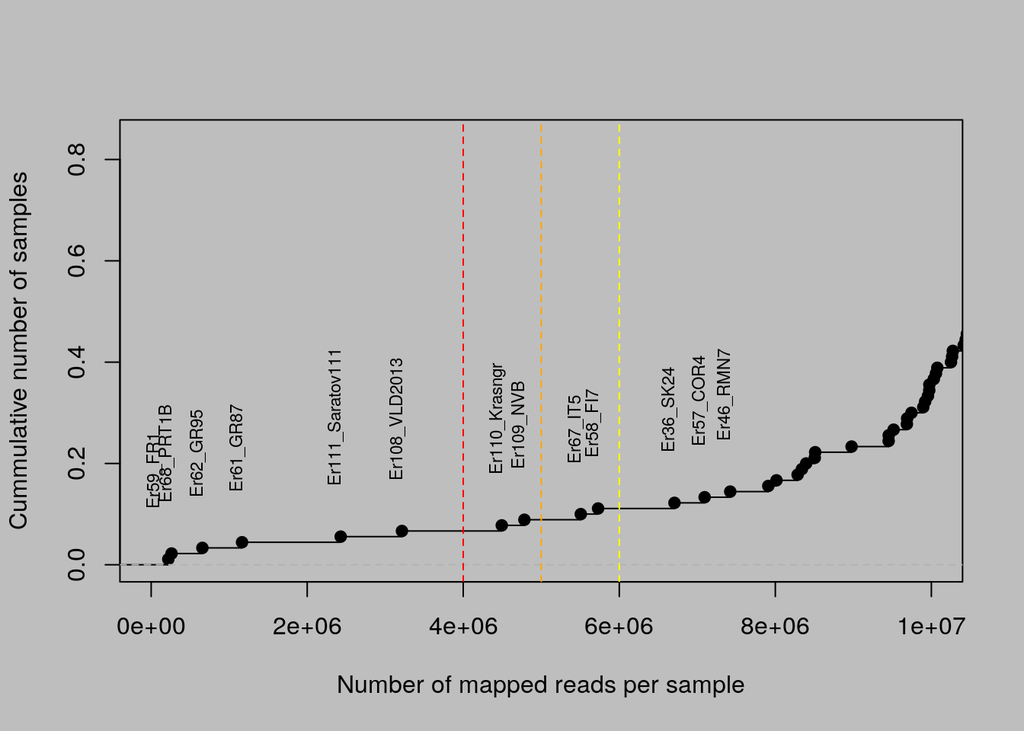

```r
par(bg = 'gray')
plot(ecdf(mapped$numReads), xlim = c(0, 1.0e+07),
     main = '',
     xlab = 'Number of mapped reads per sample',
     ylab = 'Cummulative number of samples')
abline(v = 4.0e+06, col = 'red', lty = 2)
abline(v = 5.0e+06, col = 'orange', lty = 2)
abline(v = 6.0e+06, col = 'yellow', lty = 2)

text(x = c(100000, sort(mapped$numReads)[2:13]),
     y = ecdf(mapped$numReads)(sort(mapped$numReads)[1:13]) + 0.1,
     labels = head(mapped[order(mapped$numReads), 'sample'], n = 13),
     srt = 90, adj = c(0,0), cex = 0.7)
```

```r
write.table(mapped[mapped$numReads < 4.0e+06, 'sample'],
            file = 'below4M.txt', row.names = FALSE,
            col.names = FALSE, quote = FALSE)
```

The image above shows what samples have fewer than 4 (red), 5 (orange) or 6 (yellow) million reads. Removing the 6 samples with less than 4 million reads from the beginning may be safe.

Variation in coverage comes from: random sampling of available loci, missing loci in some individuals, locus-specific mappability, repetitive content, etc. If coverage was distributed randomly across a common set of loci in every sample, coverage would not be correlated among samples. But it is (not shown), and more so among samples from the same genus. This is in part good, because the chance of covering enough a common subset of loci is higher than if there was no correlation. But it also shows that coverage is heavily affected by population-level and local factors, like structural variation and mappability issues.

Having sequenced too many loci, it is not a surprise that most individuals have more than 50% of genotypes missing. The qüestion is what is the minimum number and the identity of individuals that need to be removed to get rid of uncovered loci and to keep enough loci covered in most of the remaining individuals. If any individual was contributing a different subset of loci, for example as a consequence of spurious mappings of contaminating reads, it would be optimal to remove them, even if they have high coverage. It is unlikely, but how can I decide what are the individuals that need to be removed to improve better the overall completeness of the genotype matrix? The selection of the largest submatrix with the largest number of non-zero entries is not a trivial problem.

```bash
VCFDIR=/data/kristyna/hedgehog/results_2021/2021-04-13

# Raw, dirty vcf, 90 samples:
VCF1=$VCFDIR/all_merged_2021.vcf

if [ ! -e all.imiss ]; then
   vcftools --vcf $VCF1 \
            --out all \
            --remove below4M.txt \
            --remove-indels \
            --min-alleles 2 \
            --max-alleles 2 \
            --minQ 50 \
            --thin 261 \
            --missing-indv &> all.imiss.log &
fi

if [ ! -e all.gdepth ]; then
   vcftools --vcf $VCF1 \
            --out all \
            --remove below4M.txt \
            --remove-indels \
            --min-alleles 2 \
            --max-alleles 2 \
            --minQ 50 \
            --thin 261 \
            --geno-depth &> all.gdepth.log &
fi

wait
```

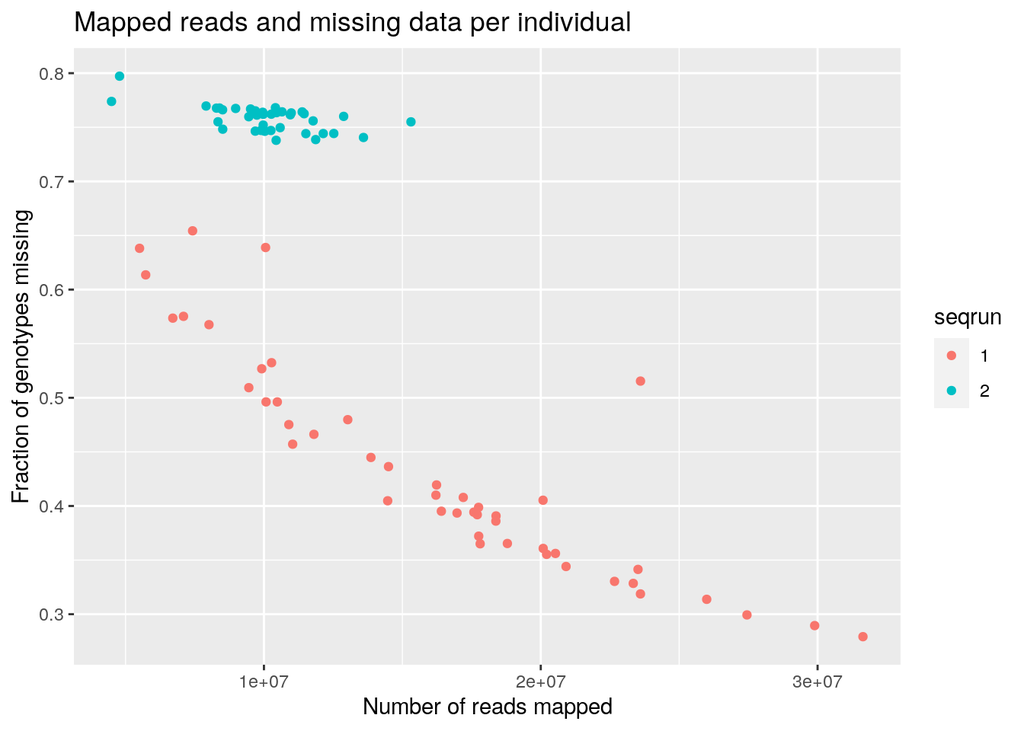

```r
library(ggplot2)
imiss <- read.table('all.imiss', header = TRUE, as.is = TRUE, row.names = 1)
row.names(mapped) <- mapped$sample
imiss$mapped <- mapped[row.names(imiss), 'numReads']
populations <- read.table('popfile.txt', row.names = 1, col.names = c('sample','pop'))
populations$seqrun <- factor(c(rep(1,50), rep(2,40)))
imiss$pop <- populations[row.names(imiss), 'pop']
imiss$seqrun <- populations[row.names(imiss), 'seqrun']
ggplot(data = imiss, mapping = aes(x = mapped, y = F_MISS, color = seqrun)) +
   geom_point() + xlab('Number of reads mapped') +
   ylab('Fraction of genotypes missing') +
   ggtitle('Mapped reads and missing data per individual')
```

So, one of the main problems is that by using a different sequencing strategy in the second sequencing run (single-read versus paired ends), many loci sequenced in the first batch are missing in the second. Presumably, because they are SNPs found in the second read.

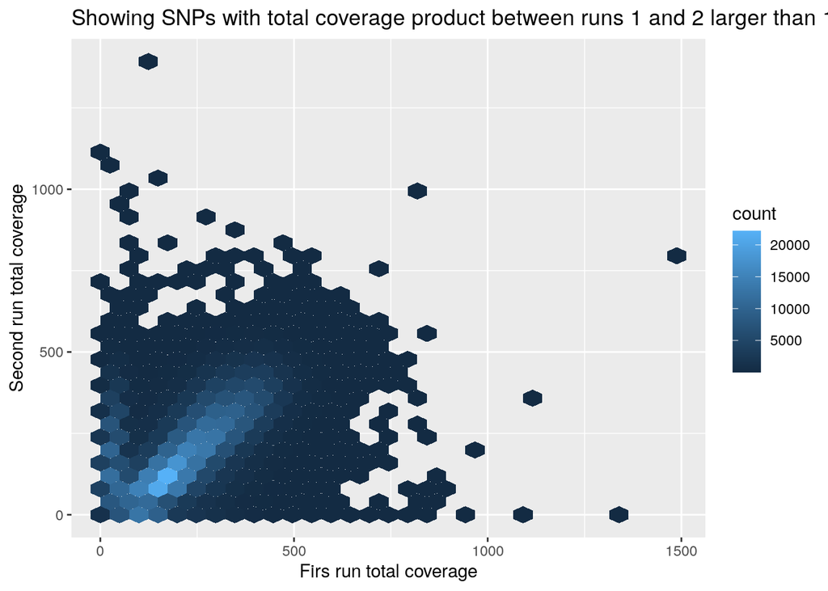

```r
library(knitr)
gdepth <- read.table('all.gdepth', header = TRUE, as.is = TRUE)
mdepth <- as.matrix(gdepth[, 3:86])
row.names(mdepth) <- paste(gdepth$CHROM, gdepth$POS, sep = ':')
mdepth[mdepth == -1] <- 0
run1 <- rownames(imiss[imiss$seqrun == 1,])
run2 <- rownames(imiss[imiss$seqrun == 2,])
runDepth <- data.frame(run1 = rowSums(mdepth[, run1]),
                       run2 = rowSums(mdepth[, run2]))
ggplot(data = runDepth[runDepth$run1 * runDepth$run2 > 100,], mapping = aes(x = run1, y = run2)) +
   geom_hex() + xlab('Firs run total coverage') + ylab('Second run total coverage') +
   ggtitle('Showing SNPs with total coverage product between runs 1 and 2 larger than 100')
```

```r
runDepthSummary <- data.frame(
   zero1 = c(sum(runDepth$run1 == 0 & runDepth$run2 == 0),
             sum(runDepth$run1 == 0 & runDepth$run2 >  0)),
   one1  = c(sum(runDepth$run1 >  0 & runDepth$run2 == 0),
             sum(runDepth$run1 >  0 & runDepth$run2 >  0))
)
row.names(runDepthSummary) <- c('Not covered in run 2','Covered in run 2')
kable(runDepthSummary, row.names = TRUE,
      col.names = c('Not covered in run 1', 'Covered in run 1'))
```

|  | Not covered in run 1 | Covered in run 1 |
| --- | --- | --- |
| Not covered in run 2 | 1140 | 1397369 |
| Covered in run 2 | 6727 | 672903 |

Still, there is a subset of sites where coverage is correlated between sequeing runs. One thing we can do to optimize the number of sites is to make sure that when we thin out the data set (to remove linkage disequilibrium) we do not remove SNPs from first reads it it is not necessary. Not sure how the thinning algorithm is implemented in vcftools, but I'm afraid that it removes SNPs based on distance, without necessarily choosing to keep the ones with higher coverage across samples.